# GAMM model for Psychotic Risk prediction from SUbstance Use and other factors in CATSS

Silpa Soni Nallacheruvu

2026-04-01

## Load the simulated Data

```r
catss <- read_csv("catss_final_data.csv")
```

## Check complete cases

```r
print(paste("Number of complete cases:", sum(complete.cases(catss))))
```

```
## [1] "Number of complete cases: 4033"
```

## Create the CCA dataset

```r
catss <- catss[complete.cases(catss), ]
```

## Split the data into training and testing dataset

Based on their twin_id

```r
test_size <- 0.25

# Get unique IDs
unique_ids <- unique(catss$cmpair)

# Sample test IDs
n_test <- floor(length(unique_ids) * test_size)
test_ids <- sample(unique_ids, size = n_test)

# Split dataset
test_df <- catss[catss$cmpair %in% test_ids, ]
train_df <- catss[!catss$cmpair %in% test_ids, ]

# Print summary
cat(sprintf(
  "Train: %d rows (%d IDs), Test: %d rows (%d IDs)\n",
  nrow(train_df), length(unique(train_df$cmpair)),
  nrow(test_df), length(unique(test_df$cmpair))
))
```

```
## Train: 3011 rows (2018 IDs), Test: 1022 rows (672 IDs)
```

## Prepare the data for the model formula by creating interaction terms and factor variables

```r
# get a list of columns with their prefix
SUD15_vars <- grep("^SUD15", names(catss), value = TRUE)
SCZ15_vars <- grep("^SCZ15", names(catss), value = TRUE)
PRS_vars <- grep("^PRS", names(catss), value = TRUE)
ADHD9_vars <- grep("^ADHD9", names(catss), value = TRUE)
ASD9_vars <- grep("^ASD9", names(catss), value = TRUE)
ACE_vars <- grep("^ACE", names(catss), value = TRUE)
SES_vars <- grep("^SES", names(catss), value = TRUE)
PCA_vars <- grep("^PC", names(catss), value = TRUE)[1:2]
Sex_var <- grep("^SEX", names(catss), value = TRUE)
Batch_var <- grep("^batch", names(catss), value = TRUE)[1]

covariate_terms <- paste(
  c(SUD15_vars, SCZ15_vars, ADHD9_vars, ASD9_vars, ACE_vars, SES_vars, paste0("s(", PRS_vars, ")"), Sex_var),
  collapse = " + "
)

# PCA terms according to the genetic batch
genetic_confounding_terms <- paste(
  c(
    paste0("factor(", Batch_var, ") : ", PCA_vars)
  ),
  collapse = " + "
)

# create interaction terms between SUD15 variables and all other covariates
interaction_terms <- paste(
  c(
    paste0(SUD15_vars ,":", SCZ15_vars),
    paste0(SUD15_vars, ":", ADHD9_vars),
    paste0(SUD15_vars, ":", ASD9_vars),
    paste0(SUD15_vars, ":", ACE_vars),
    paste0(SUD15_vars, ":", SES_vars),
    paste0(SUD15_vars, ":", PRS_vars),
    paste0(SUD15_vars, ":", Sex_var)
  ),
  collapse = " + "
)

train_df$cmpair <- as.factor(train_df$cmpair)
```

# Fit the GAMM model

## Fit the Positive GAMM model

```r
pos_gamm_formula_str <- paste(
  "SCZ18_Pos_Norm ~",
  covariate_terms, "+",
  genetic_confounding_terms, "+",
  interaction_terms, "+",
  "s(cmpair, bs='re')"
)

pos_gamm_formula <- as.formula(pos_gamm_formula_str)

pos_gamm_model <- gam(
  pos_gamm_formula,
  data = train_df,
  family = gaussian(),
  method = "REML"
)

summary(pos_gamm_model)
```

```
##
## Family: gaussian
## Link function: identity
##
## Formula:
## SCZ18_Pos_Norm ~ SUD15_Cigarettes15 + SUD15_Snuff15 + SUD15_Alcohol15 +
##     SUD15_Cannabis15 + SUD15_Painkillers_opioids15 + SUD15_OtherDrugs15 +
##     SCZ15_Spied15 + SCZ15_Others_Read_thoughts15 + SCZ15_Special_messages15 +
##     SCZ15_Special_powers15 + SCZ15_Under_control_special_power15 +
##     SCZ15_Read_others_minds15 + SCZ15_Seen_hallucinations15 +
##     SCZ15_Extreme_excitement15 + SCZ15_Irritable15 + SCZ15_Unrealistic_abilities15 +
##     SCZ15_Not_tired15 + SCZ15_Too_much_energy15 + SCZ15_Racing_thoughts15 +
##     SCZ15_Talking_fast15 + SCZ15_Sexual_inappropriate15 + SCZ15_Rage_attacks15 +
##     SCZ15_Hear_voices15 + SCZ15_headaches15 + SCZ15_worry15 +
##     SCZ15_unhappy15 + SCZ15_lose_confidence15 + SCZ15_easily_scared15 +
##     SCZ15_PROD_seen_hallucinations9 + ADHD9_fail_close_attention9 +
##     ADHD9_difficulty_with_attention9 + ADHD9_not_listening9 +
##     ADHD9_difficulty_following_instructions9 + ADHD9_difficulty_organizing_tasks9 +
##     ADHD9_avoid_mental_effort_tasks9 + ADHD9_often_lose_things9 +
##     ADHD9_easily_distracted9 + ADHD9_often_forgetful9 + ADHD9_difficulty_hold_still9 +
##     ADHD9_often_move9 + ADHD9_often_run9 + ADHD9_difficulty_calm9 +
##     ADHD9_often_motor9 + ADHD9_talk_excess9 + ADHD9_often_blurt_out9 +
##     ADHD9_difficulty_waiting9 + ADHD9_often_interrupt9 + ADHD9_easily_bored9 +
##     ASD9_delay_language9 + ASD9_difficulty_converse9 + ASD9_repeat_words9 +
##     ASD9_difficulty_pretend_play9 + ASD9_talk_too_high_low9 +
##     ASD9_difficulty_on_track9 + ASD9_difficulty_express9 + ASD9_difficulty_socialize9 +
##     ASD9_uninterested_sharing9 + ASD9_own_terms9 + ASD9_difficulty_expect_behavior9 +
##     ASD9_easily_influenced9 + ASD9_absorbed_own9 + ASD9_absorbed_problems9 +
##     ASD9_strange_movements9 + ASD9_absorbed_details9 + ASD9_dislike_change9 +
##     ACE15_bullied_often15 + ACE15_tease_bullying15 + ACE15_emotional_bullying15 +
##     ACE15_rumours_bullying15 + ACE15_bullying_by_num15 + ACE15_bullying_time15 +
##     ACE18_emotional_abuse18 + ACE18_witness_crime18 + ACE18_hate_crime18 +
##     ACE15_other_bullying15 + ACE18_other_abuse18 + SES_birth_country_mother +
##     SES_education_mother + SES_birth_country_father + SES_education_father +
##     s(PRS_Amygdala_excitatory) + s(PRS_Cerebellar_inhibitory) +
##     s(PRS_CGE_interneuron) + s(PRS_Deep_layer_corticothalamic) +
##     s(PRS_Deep_layer_intratelencepha) + s(PRS_Eccentric_medium_spiny_neu) +
##     s(PRS_Hippocampal_CA1_3) + s(PRS_Hippocampal_CA4) + s(PRS_Hippocampal_dentate_gyrus) +
##     s(PRS_LAMP5_LHX6_and_Chandelier) + s(PRS_Medium_spiny_neuron) +
##     s(PRS_MGE_interneuron) + s(PRS_Miscellaneous) + s(PRS_Thalamic_excitatory) +
```

[output cut: 814 more lines]

```
## s(PRS_Hippocampal_dentate_gyrus)    1.000    1.000 0.024  0.8765
## s(PRS_LAMP5_LHX6_and_Chandelier)    1.001    1.002 0.065  0.8004
## s(PRS_Medium_spiny_neuron)          1.099    1.175 0.144  0.8487
## s(PRS_MGE_interneuron)              1.001    1.001 0.530  0.4666
## s(PRS_Miscellaneous)                1.000    1.000 0.448  0.5036
## s(PRS_Thalamic_excitatory)          1.000    1.001 0.992  0.3194
## s(PRS_Upper_layer_intratelenceph)   1.000    1.000 1.702  0.1922
## s(PRS_all)                          1.000    1.001 4.013  0.0452 *
## s(cmpair)                         348.250 2012.000 0.216  <2e-16 ***
## ---
## Signif. codes:  0 '***' 0.001 '**' 0.01 '*' 0.05 '.' 0.1 ' ' 1
##
## Rank: 2347/2348
## R-sq.(adj) =  0.361   Deviance explained = 47.9%
## -REML = -2373.8  Scale est. = 0.0064901  n = 3011
```

### View significance

```r
param_coefs <- as.data.frame(summary(pos_gamm_model)$p.table)

smooth_coefs <- as.data.frame(summary(pos_gamm_model)$s.table)

# Prepare clean table
pos_coefs_table <- param_coefs %>%
  mutate(Variable = rownames(.)) %>%
  rename(p_value = `Pr(>|t|)`) %>%
  mutate(significance = cut(
    p_value,
    breaks = c(-Inf, 0.001, 0.01, 0.05, 0.1, Inf),
    labels = c("***", "**", "*", ".", "")
  )) %>%
  filter(p_value < 0.05, Variable != "(Intercept)") %>%
  arrange(p_value) %>%
  select(Estimate, `Std. Error`, p_value, significance) %>%
  mutate(
    Estimate = round(Estimate, 3),
    `Std. Error` = round(`Std. Error`, 3),
    p_value = signif(p_value, 3)
  )

kable(pos_coefs_table, format = "html") %>%
  kable_styling(bootstrap_options = c("striped", "hover", "condensed"))
```

Estimate

Std. Error

p_value

significance

ACE18_emotional_abuse18

-0.038

0.004

0.00e+00

***

SCZ15_Extreme_excitement15

0.010

0.002

2.00e-07

***

SCZ15_Seen_hallucinations15

0.021

0.004

2.70e-06

***

SCZ15_Too_much_energy15

0.010

0.003

4.07e-05

***

ACE18_witness_crime18

-0.024

0.006

1.48e-04

***

SCZ15_headaches15

0.009

0.003

1.21e-03

SCZ15_Special_messages15

0.078

0.024

1.53e-03

ACE15_emotional_bullying15

0.040

0.013

2.18e-03

SCZ15_Talking_fast15

0.008

0.003

2.27e-03

SCZ15_Read_others_minds15

0.007

0.002

5.45e-03

SUD15_OtherDrugs15:PRS_MGE_interneuron

0.113

0.043

9.63e-03

SUD15_Alcohol15:ACE15_emotional_bullying15

-0.009

0.004

1.24e-02

SUD15_Alcohol15:SCZ15_Special_messages15

-0.017

0.007

1.35e-02

SUD15_OtherDrugs15:PRS_Eccentric_medium_spiny_neu

0.099

0.040

1.36e-02

SUD15_Painkillers_opioids15:ACE18_other_abuse18

0.373

0.156

1.69e-02

SCZ15_Rage_attacks15

0.009

0.004

1.79e-02

SUD15_Snuff15:SCZ15_Extreme_excitement15

-0.007

0.003

1.83e-02

SUD15_Painkillers_opioids15:SCZ15_Under_control_special_power15

-0.014

0.006

1.84e-02

SCZ15_Spied15

0.007

0.003

2.15e-02

SUD15_Alcohol15:PRS_CGE_interneuron

0.034

0.016

2.81e-02

SUD15_Painkillers_opioids15

-0.343

0.158

3.00e-02

ASD9_easily_influenced9

0.008

0.004

4.61e-02

### Check the twin random effect

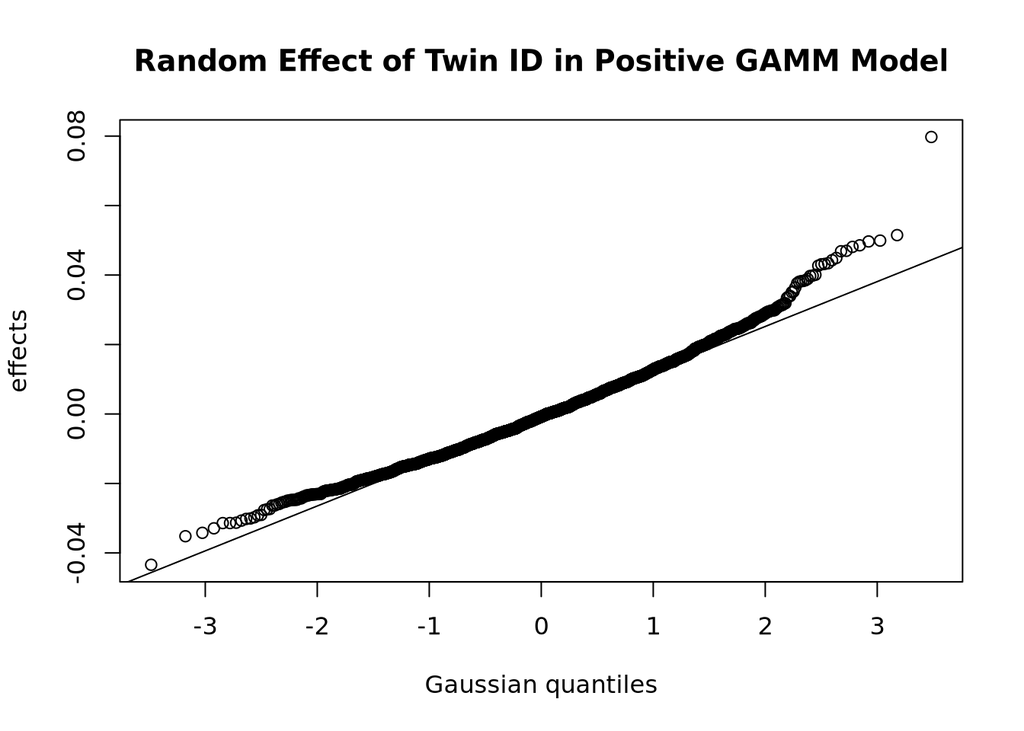

```r
plot(pos_gamm_model, select = 17, main = "Random Effect of Twin ID in Positive GAMM Model")
```

### Evaluate the model predictions

```r
pos_gamm_y_pred <- predict(pos_gamm_model, newdata = test_df, type = "response")
```

[output not shown]

[output cut: 31 more lines]

[output not shown]

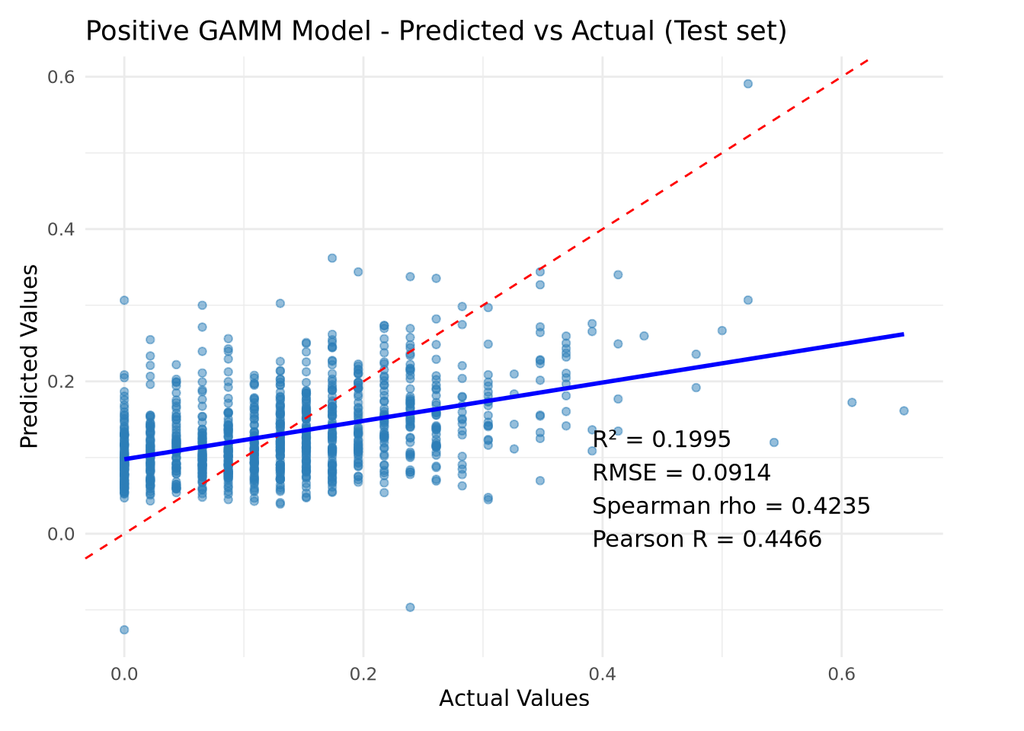

```r
pos_y_true <- test_df$SCZ18_Pos_Norm

# Create dataframe
pos_gamm_df <- data.frame(
  actual = pos_y_true,
  predicted = pos_gamm_y_pred
)

# Residuals
pos_gamm_df$residuals <- pos_gamm_df$actual - pos_gamm_df$predicted

# Metrics
r2 <- cor(pos_gamm_df$actual, pos_gamm_df$predicted)^2
rmse <- sqrt(mean((pos_gamm_df$actual - pos_gamm_df$predicted)^2))
pearson_r <- cor(pos_gamm_df$actual, pos_gamm_df$predicted)
spearman_r <- cor(pos_gamm_df$actual, pos_gamm_df$predicted, method = "spearman")

metrics_text <- sprintf(
  "R² = %.4f\nRMSE = %.4f\nSpearman rho = %.4f\nPearson R = %.4f",
  r2, rmse, spearman_r, pearson_r
)

# predicted vs actual plot
p1 <- ggplot(pos_gamm_df, aes(x = actual, y = predicted)) +
  geom_point(alpha = 0.5, color = "#2C7FB8") +
  geom_abline(intercept = 0, slope = 1, linetype = "dashed", color = "red") +
  geom_smooth(method = "lm", se = FALSE, color = "blue") +

  annotate("text",
           x = max(pos_gamm_df$actual) * 0.6,
           y = max(pos_gamm_df$predicted) * 0.1,   # move inside plot
           label = metrics_text,
           hjust = 0,
           size = 4) +

  coord_cartesian(clip = "off") +  # prevents clipping

  labs(
    title = "Positive GAMM Model - Predicted vs Actual (Test set)",
    x = "Actual Values",
    y = "Predicted Values"
  ) +
  theme_minimal() +
  theme(plot.margin = margin(10, 40, 10, 10))  # extra space

p1
```

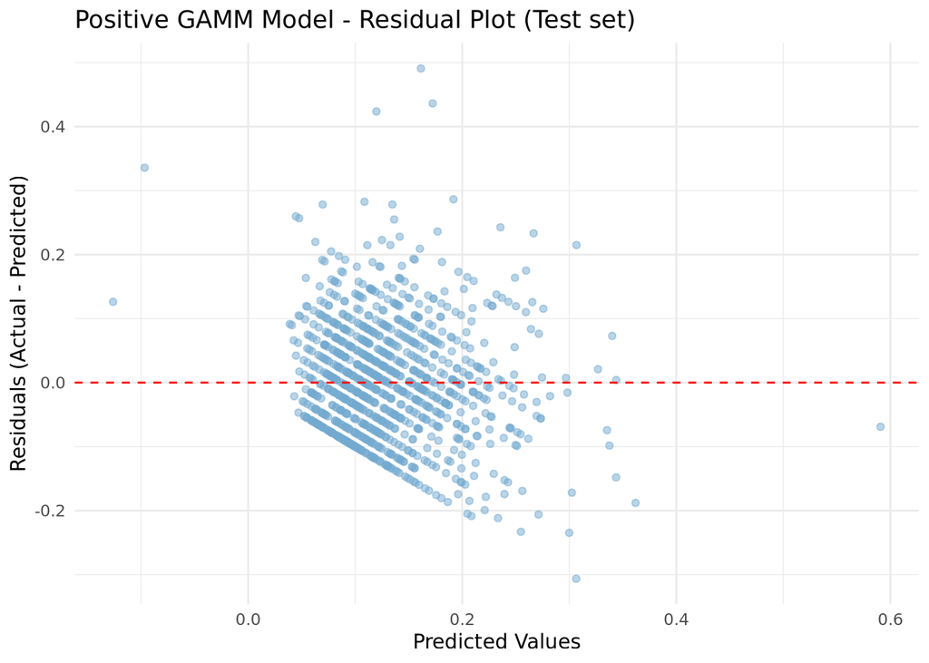

```r
# residual plot
p2 <- ggplot(pos_gamm_df, aes(x = predicted, y = residuals)) +
  geom_point(alpha = 0.5, color = "#74A9CF") +
  geom_hline(yintercept = 0, linetype = "dashed", color = "red") +

  labs(
    title = "Positive GAMM Model - Residual Plot (Test set)",
    x = "Predicted Values",
    y = "Residuals (Actual - Predicted)"
  ) +
  theme_minimal()

p2
```

## Fit the Negative GAMM model

```r
neg_gamm_formula_str <- paste(
  "SCZ18_Neg_Norm ~",
  covariate_terms, "+",
  genetic_confounding_terms, "+",
  interaction_terms, "+",
  "s(cmpair, bs='re')"
)

neg_gamm_formula <- as.formula(neg_gamm_formula_str)

neg_gamm_model <- gam(
  neg_gamm_formula,
  data = train_df,
  family = gaussian(),
  method = "REML"
)

summary(neg_gamm_model)
```

```
##
## Family: gaussian
## Link function: identity
##
## Formula:
## SCZ18_Neg_Norm ~ SUD15_Cigarettes15 + SUD15_Snuff15 + SUD15_Alcohol15 +
##     SUD15_Cannabis15 + SUD15_Painkillers_opioids15 + SUD15_OtherDrugs15 +
##     SCZ15_Spied15 + SCZ15_Others_Read_thoughts15 + SCZ15_Special_messages15 +
##     SCZ15_Special_powers15 + SCZ15_Under_control_special_power15 +
##     SCZ15_Read_others_minds15 + SCZ15_Seen_hallucinations15 +
##     SCZ15_Extreme_excitement15 + SCZ15_Irritable15 + SCZ15_Unrealistic_abilities15 +
##     SCZ15_Not_tired15 + SCZ15_Too_much_energy15 + SCZ15_Racing_thoughts15 +
##     SCZ15_Talking_fast15 + SCZ15_Sexual_inappropriate15 + SCZ15_Rage_attacks15 +
##     SCZ15_Hear_voices15 + SCZ15_headaches15 + SCZ15_worry15 +
##     SCZ15_unhappy15 + SCZ15_lose_confidence15 + SCZ15_easily_scared15 +
##     SCZ15_PROD_seen_hallucinations9 + ADHD9_fail_close_attention9 +
##     ADHD9_difficulty_with_attention9 + ADHD9_not_listening9 +
##     ADHD9_difficulty_following_instructions9 + ADHD9_difficulty_organizing_tasks9 +
##     ADHD9_avoid_mental_effort_tasks9 + ADHD9_often_lose_things9 +
##     ADHD9_easily_distracted9 + ADHD9_often_forgetful9 + ADHD9_difficulty_hold_still9 +
##     ADHD9_often_move9 + ADHD9_often_run9 + ADHD9_difficulty_calm9 +
##     ADHD9_often_motor9 + ADHD9_talk_excess9 + ADHD9_often_blurt_out9 +
##     ADHD9_difficulty_waiting9 + ADHD9_often_interrupt9 + ADHD9_easily_bored9 +
##     ASD9_delay_language9 + ASD9_difficulty_converse9 + ASD9_repeat_words9 +
##     ASD9_difficulty_pretend_play9 + ASD9_talk_too_high_low9 +
##     ASD9_difficulty_on_track9 + ASD9_difficulty_express9 + ASD9_difficulty_socialize9 +
##     ASD9_uninterested_sharing9 + ASD9_own_terms9 + ASD9_difficulty_expect_behavior9 +
##     ASD9_easily_influenced9 + ASD9_absorbed_own9 + ASD9_absorbed_problems9 +
##     ASD9_strange_movements9 + ASD9_absorbed_details9 + ASD9_dislike_change9 +
##     ACE15_bullied_often15 + ACE15_tease_bullying15 + ACE15_emotional_bullying15 +
##     ACE15_rumours_bullying15 + ACE15_bullying_by_num15 + ACE15_bullying_time15 +
##     ACE18_emotional_abuse18 + ACE18_witness_crime18 + ACE18_hate_crime18 +
##     ACE15_other_bullying15 + ACE18_other_abuse18 + SES_birth_country_mother +
##     SES_education_mother + SES_birth_country_father + SES_education_father +
##     s(PRS_Amygdala_excitatory) + s(PRS_Cerebellar_inhibitory) +
##     s(PRS_CGE_interneuron) + s(PRS_Deep_layer_corticothalamic) +
##     s(PRS_Deep_layer_intratelencepha) + s(PRS_Eccentric_medium_spiny_neu) +
##     s(PRS_Hippocampal_CA1_3) + s(PRS_Hippocampal_CA4) + s(PRS_Hippocampal_dentate_gyrus) +
##     s(PRS_LAMP5_LHX6_and_Chandelier) + s(PRS_Medium_spiny_neuron) +
##     s(PRS_MGE_interneuron) + s(PRS_Miscellaneous) + s(PRS_Thalamic_excitatory) +
```

[output cut: 814 more lines]

```
## s(PRS_Hippocampal_dentate_gyrus)    1.519    1.833 0.546  0.6401
## s(PRS_LAMP5_LHX6_and_Chandelier)    1.000    1.000 0.279  0.5977
## s(PRS_Medium_spiny_neuron)          1.000    1.000 0.970  0.3248
## s(PRS_MGE_interneuron)              1.000    1.000 0.272  0.6019
## s(PRS_Miscellaneous)                1.000    1.000 0.309  0.5785
## s(PRS_Thalamic_excitatory)          2.250    2.793 1.249  0.3365
## s(PRS_Upper_layer_intratelenceph)   1.000    1.000 3.496  0.0616 .
## s(PRS_all)                          1.000    1.000 6.499  0.0109 *
## s(cmpair)                         385.150 2012.000 0.244  <2e-16 ***
## ---
## Signif. codes:  0 '***' 0.001 '**' 0.01 '*' 0.05 '.' 0.1 ' ' 1
##
## Rank: 2347/2348
## R-sq.(adj) =  0.378   Deviance explained =   50%
## -REML = -813.82  Scale est. = 0.019384  n = 3011
```

### View significance

```r
param_coefs <- as.data.frame(summary(neg_gamm_model)$p.table)

smooth_coefs <- as.data.frame(summary(neg_gamm_model)$s.table)

# Prepare clean table
neg_coefs_table <- param_coefs %>%
  mutate(Variable = rownames(.)) %>%
  rename(p_value = `Pr(>|t|)`) %>%
  mutate(significance = cut(
    p_value,
    breaks = c(-Inf, 0.001, 0.01, 0.05, 0.1, Inf),
    labels = c("***", "**", "*", ".", "")
  )) %>%
  filter(p_value < 0.05, Variable != "(Intercept)") %>%
  arrange(p_value) %>%
  select(Estimate, `Std. Error`, p_value, significance) %>%
  mutate(
    Estimate = round(Estimate, 3),
    `Std. Error` = round(`Std. Error`, 3),
    p_value = signif(p_value, 3)
  )

kable(neg_coefs_table, format = "html") %>%
  kable_styling(bootstrap_options = c("striped", "hover", "condensed"))
```

Estimate

Std. Error

p_value

significance

ACE18_emotional_abuse18

-0.082

0.007

0.000000

***

SCZ15_unhappy15

0.041

0.006

0.000000

***

SCZ15_headaches15

0.030

0.005

0.000000

***

SCZ15_worry15

0.019

0.005

0.000136

***

SCZ15_Extreme_excitement15

-0.012

0.003

0.000250

***

SCZ15_Too_much_energy15

0.013

0.004

0.003130

SUD15_Cigarettes15:ADHD9_difficulty_calm9

0.042

0.015

0.005550

factor(batch)GSA3:PC1

-3.006

1.087

0.005710

SUD15_Alcohol15:ASD9_uninterested_sharing9

0.057

0.021

0.007760

ASD9_uninterested_sharing9

-0.190

0.076

0.013000

SUD15_Snuff15:ASD9_difficulty_socialize9

-0.075

0.031

0.014500

ADHD9_often_blurt_out9

-0.019

0.008

0.016300

SUD15_Cigarettes15:SCZ15_worry15

-0.013

0.005

0.017400

ASD9_repeat_words9

-0.117

0.050

0.018200

SUD15_Alcohol15:ASD9_repeat_words9

0.031

0.013

0.021500

SEX

0.056

0.025

0.025500

ASD9_talk_too_high_low9

0.020

0.009

0.028900

SUD15_Painkillers_opioids15:ASD9_talk_too_high_low9

-0.052

0.024

0.029100

SUD15_OtherDrugs15:SCZ15_headaches15

0.027

0.012

0.031700

factor(batch)GSA3:PC2

2.270

1.096

0.038500

SCZ15_Rage_attacks15

0.014

0.007

0.039600

ACE15_emotional_bullying15

0.047

0.023

0.040200

SUD15_Alcohol15:PRS_Upper_layer_intratelenceph

0.058

0.029

0.041300

SCZ15_Special_powers15

-0.022

0.011

0.044200

factor(batch)GSA1:PC1

0.862

0.435

0.047400

### Check the twin random effect

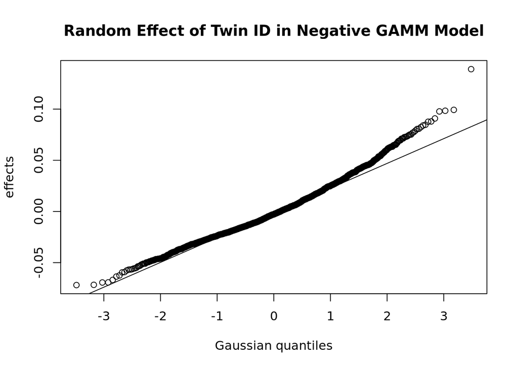

```r
plot(neg_gamm_model, select = 17, main = "Random Effect of Twin ID in Negative GAMM Model")
```

### Evaluate the model predictions

```r
neg_gamm_y_pred <- predict(neg_gamm_model, newdata = test_df, type = "response")
```

[output not shown]

[output cut: 31 more lines]

[output not shown]

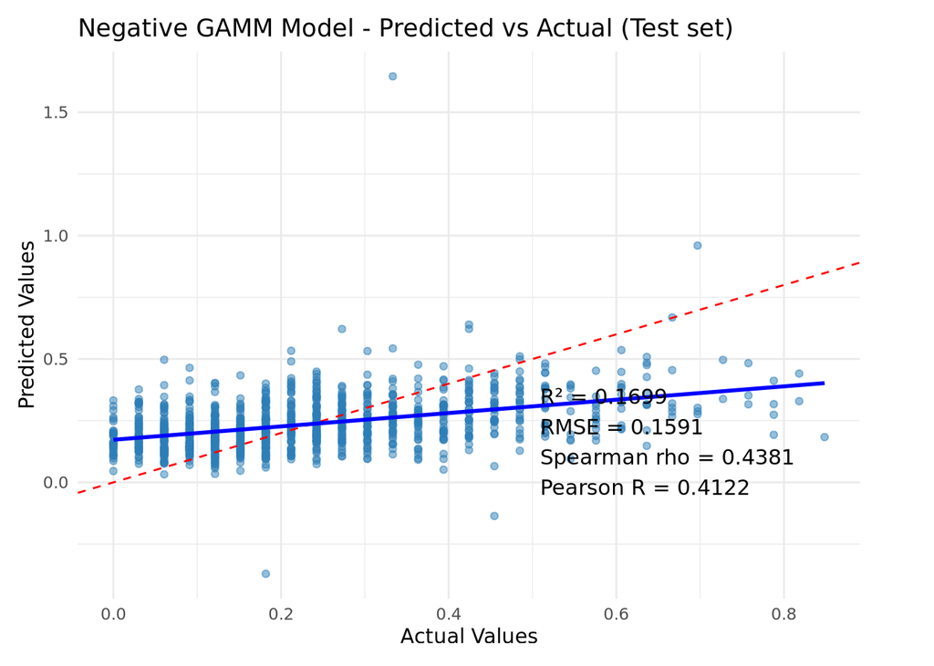

```r
neg_y_true <- test_df$SCZ18_Neg_Norm

# Create data frame
neg_gamm_df <- data.frame(
  actual = neg_y_true,
  predicted = neg_gamm_y_pred
)

# Residuals
neg_gamm_df$residuals <- neg_gamm_df$actual - neg_gamm_df$predicted

# Metrics
r2 <- cor(neg_gamm_df$actual, neg_gamm_df$predicted)^2
rmse <- sqrt(mean((neg_gamm_df$actual - neg_gamm_df$predicted)^2))
pearson_r <- cor(neg_gamm_df$actual, neg_gamm_df$predicted)
spearman_r <- cor(neg_gamm_df$actual, neg_gamm_df$predicted, method = "spearman")

metrics_text <- sprintf(
  "R² = %.4f\nRMSE = %.4f\nSpearman rho = %.4f\nPearson R = %.4f",
  r2, rmse, spearman_r, pearson_r
)

# predicted vs actual plot
p1 <- ggplot(neg_gamm_df, aes(x = actual, y = predicted)) +
  geom_point(alpha = 0.5, color = "#2C7FB8") +
  geom_abline(intercept = 0, slope = 1, linetype = "dashed", color = "red") +
  geom_smooth(method = "lm", se = FALSE, color = "blue") +

  annotate("text",
           x = max(neg_gamm_df$actual) * 0.6,
           y = max(neg_gamm_df$predicted) * 0.1,   # move inside plot
           label = metrics_text,
           hjust = 0,
           size = 4) +

  coord_cartesian(clip = "off") +  # prevents clipping

  labs(
    title = "Negative GAMM Model - Predicted vs Actual (Test set)",
    x = "Actual Values",
    y = "Predicted Values"
  ) +
  theme_minimal() +
  theme(plot.margin = margin(10, 40, 10, 10))  # extra space

p1
```

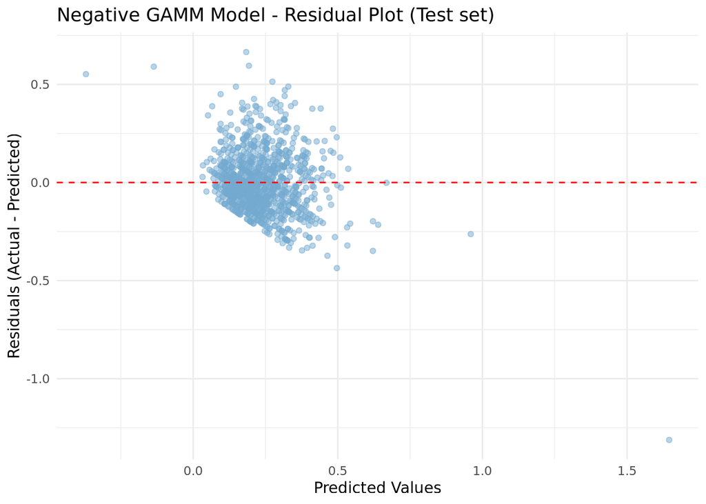

```r
# residual plot
p2 <- ggplot(neg_gamm_df, aes(x = predicted, y = residuals)) +
  geom_point(alpha = 0.5, color = "#74A9CF") +
  geom_hline(yintercept = 0, linetype = "dashed", color = "red") +

  labs(
    title = "Negative GAMM Model - Residual Plot (Test set)",
    x = "Predicted Values",
    y = "Residuals (Actual - Predicted)"
  ) +
  theme_minimal()

p2
```